# San Juan escapement 2025 (PRELIM)

South Coast StA

Last update: 2026-04-14

Mini tribs were surveyed this year and mostly entered under San Juan mainstem as reaches. Three are not in the database and need to be added next year: Dr Dave Creek, Chim’s Channel, and Stanley Creek. These are all part of the San Juan mainstem estimate, but are not of concern because 1) all with the exception of Kuzman are d/s of the standard snorkel area, and 2) hardly any fish were seen in 2025 in these creeks.

# 1 **Sockeye**

## 1.1 Area 20 raw vs expanded counts

Counts are expanded for % population estimated and/or observer efficiency, depending on survey conditions.

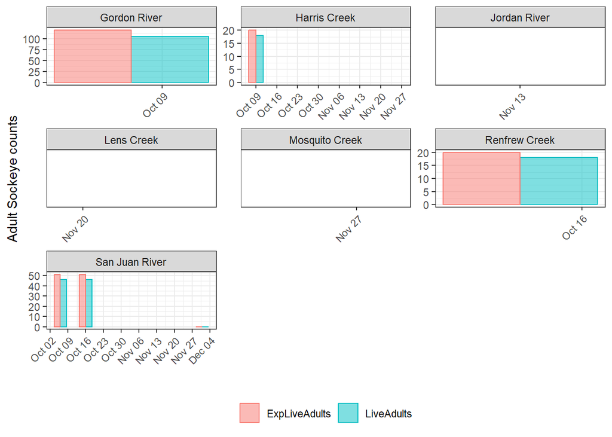

Figure: Observed Adult Sockeye counts (blue) and expanded for OE/%habitat (pink).

## 1.2 Counts & environmentals

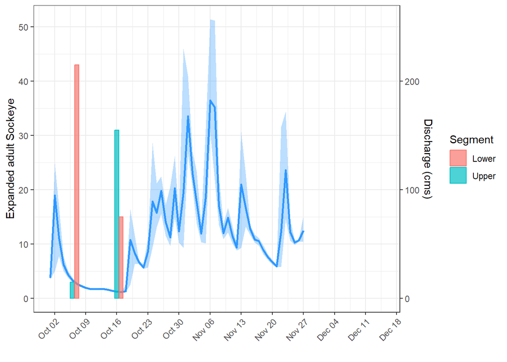

Figure: Sockeye raw counts (live adults) and water levels (blue line) in the San Juan mainstem.

## 1.3 Behaviour & carcasses

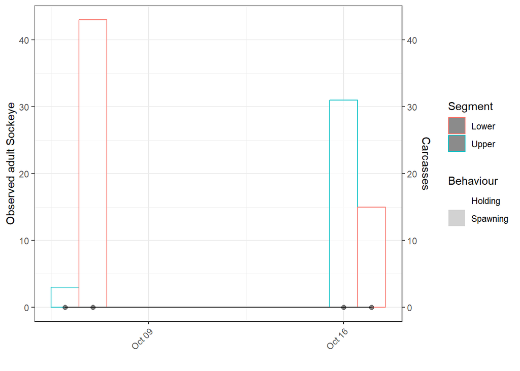

Figure: Raw live adult Sockeye (bars) and carcasses (black line) in the San Juan mainstem. Bar fill colour indicates behaviour (spawning=gray, holding=white) while bar outline colour indicates river segment (lower=pink, mid=green, upper=blue). Note Oct 3/4 “mid” section was covered within upper and lower segments.

## 1.4 Swim & fence counts

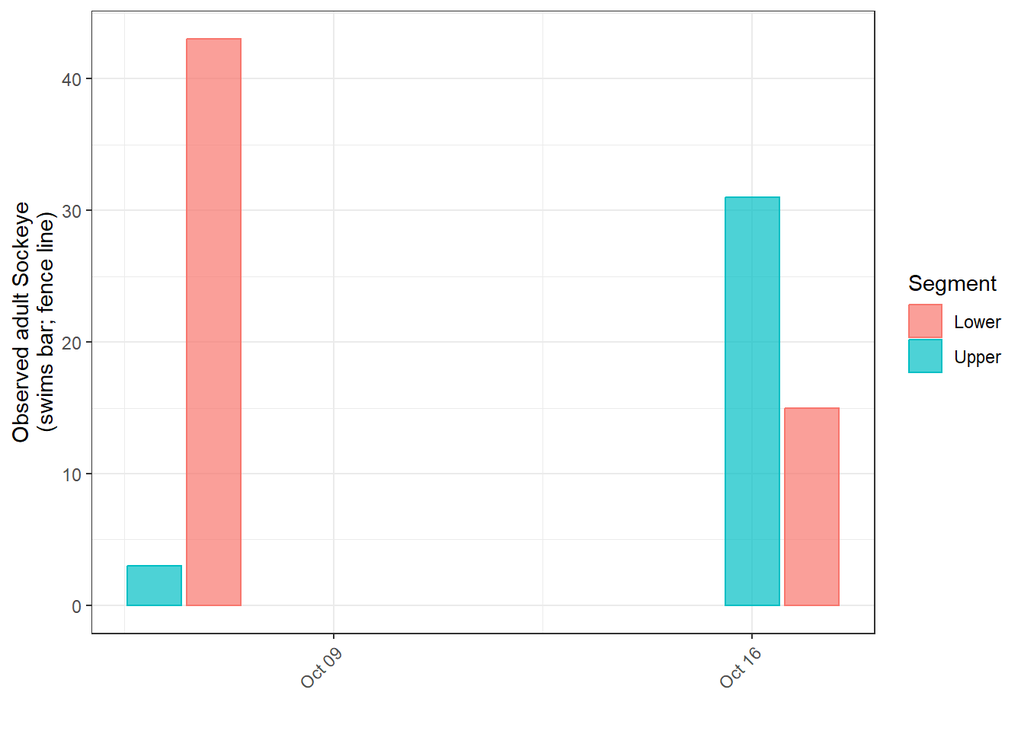

Figure: Sockeye swim counts (raw adults) in the San Juan mainstem relative to cumulative fence counts (black line). If no black line, then no Sockeye were counted through the fence this year.

[figure not shown]

## 1.5 Tributaries/Non-San Juan

| trib_status | system | date | expanded_live_adults | dead_adults |
| --- | --- | --- | --- | --- |
| SJ trib | Harris | 2025-10-10 | 18 | 0 |
|  | Renfrew | 2025-10-14 | 14 | 0 |
|  | Renfrew | 2025-10-15 | 4 | 0 |
| NA | Gordon | 2025-10-08 | 105 | 0 |

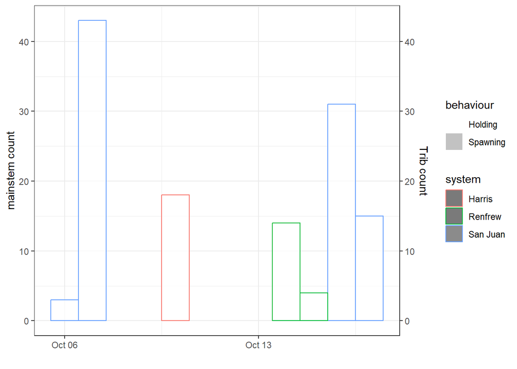

Figure: San Juan Mainstem and trib counts for Sockeye adults (raw).

## 1.6 Area 20 preliminary escapement estimates (PL+D)

Table: San Juan raw swim data (raw and expanded live and dead) for Sockeye.

| ShortSpecies | Section_AreaInspected | SDate | WaterTemperature | WaterClarity | LiveAdults | DeadAdults | LiveJacks | DeadJacks | ExpLiveAdults | ExpDeadAdults | ExpLiveJacks | ExpDeadJacks | OverallReliability | EstPctSeen |
| --- | --- | --- | --- | --- | --- | --- | --- | --- | --- | --- | --- | --- | --- | --- |
| SK | FAIRY CREEK | 2025-11-25 | 99.0 | NA | NA | NA | NA | NA | NA | NA | NA | NA | NA | NA |
|  | FALLS CREEK | 2025-11-26 |  | NA | NA | NA | NA | NA | NA | NA | NA | NA | NA | NA |
|  | GORDON RIVER | 2025-10-08 | 9.5 | 3 - 5 m or to Bottom | 105 | NA | NA | NA | 117 | NA | NA | NA | H | 0.9 |
|  | HARRIS CREEK | 2025-10-09 | 11.5 | 3 - 5 m or to Bottom | 18 | NA | NA | NA | 18 | NA | NA | NA | H | 1.0 |
|  |  | 2025-11-25 | 99.0 | NA | NA | NA | NA | NA | NA | NA | NA | NA | NA | NA |
|  | JORDAN RIVER | 2025-11-13 | 9.0 | 3 - 5 m or to Bottom | NA | NA | NA | NA | NA | NA | NA | NA | NA | NA |
|  | LENS CREEK | 2025-11-21 | 8.0 | 3 - 5 m or to Bottom | NA | NA | NA | NA | NA | NA | NA | NA | NA | NA |
|  |  | 2025-11-24 | 99.0 | NA | NA | NA | NA | NA | NA | NA | NA | NA | NA | NA |
|  | MOSQUITO CREEK | 2025-11-26 |  | NA | NA | NA | NA | NA | NA | NA | NA | NA | NA | NA |
|  | RENFREW CREEK | 2025-10-14 | 9.0 | 3 - 5 m or to Bottom | 14 | NA | NA | NA | 14 | NA | NA | NA | H | 1.0 |
|  |  | 2025-10-15 |  | 3 - 5 m or to Bottom | 4 | NA | NA | NA | 4 | NA | NA | NA | H | 1.0 |
|  | SAN JUAN RIVER | 2025-10-06 | 10.0 | 3 - 5 m or to Bottom | 3 | 0 | NA | NA | 3 | NA | NA | NA | H | 1.0 |
|  |  | 2025-10-07 | 10.5 | 3 - 5 m or to Bottom | 43 | 0 | NA | NA | 43 | NA | NA | NA | H | 1.0 |
|  |  | 2025-10-16 | 6.0 | 3 - 5 m or to Bottom | 31 | NA | NA | NA | 31 | NA | NA | NA | H | 1.0 |
|  |  | 2025-10-17 | 10.5 | 3 - 5 m or to Bottom | 15 | NA | NA | NA | 15 | NA | NA | NA | H | 1.0 |
|  |  | 2025-12-01 | 4.0 | 3 - 5 m or to Bottom | NA | NA | NA | NA | NA | NA | NA | NA | NA | NA |
|  |  | 2025-12-03 | 4.5 | 3 - 5 m or to Bottom | NA | NA | NA | NA | NA | NA | NA | NA | NA | NA |

Table: Escapement estimates for each system. San Juan mainstem surveys were rolled up based on mid-point date for each of 3 complete survey events, and then the PL+D was selected based on the 3 survey events.

| ShortSpecies | SystemName | AdultRawPLD | AdultExpPLD | JackRawPLD | JackExpPLD | AdultRemovalsReco | JackRemovalsReco | FinalAdultEstimate | FinalJackEstimate |
| --- | --- | --- | --- | --- | --- | --- | --- | --- | --- |
| SK | Jordan River | 0 | 0 | 0 | 0 | 0 | 0 | 0 | 0 |
| SK | San Juan River | 46 | 51 | 0 | 0 | 0 | 0 | 51 | 0 |
| SK | Falls Creek | 0 | 0 | 0 | 0 | 0 | 0 | 0 | 0 |
| SK | Mosquito Creek | 0 | 0 | 0 | 0 | 0 | 0 | 0 | 0 |
| SK | Fairy Creek | 0 | 0 | 0 | 0 | 0 | 0 | 0 | 0 |
| SK | Renfrew Creek | 18 | 20 | 0 | 0 | 0 | 0 | 20 | 0 |
| SK | Harris Creek | 18 | 20 | 0 | 0 | 0 | 0 | 20 | 0 |
| SK | Lens Creek | 0 | 0 | 0 | 0 | 0 | 0 | 0 | 0 |
| SK | Gordon River | 105 | 119 | 0 | 0 | 0 | 0 | 119 | 0 |

### 1.6.1 Estimate decision:

For 2025 estimates used PL+D. No SK counted through the fence. Kept SJ as-is because counts before and after tribs were almost identical. Harris/Lens/Renfrew will be in addition to the San Juan PL+D estimate (i.e., no subtractions this year).

## 1.7 2025 compared to historical abundance

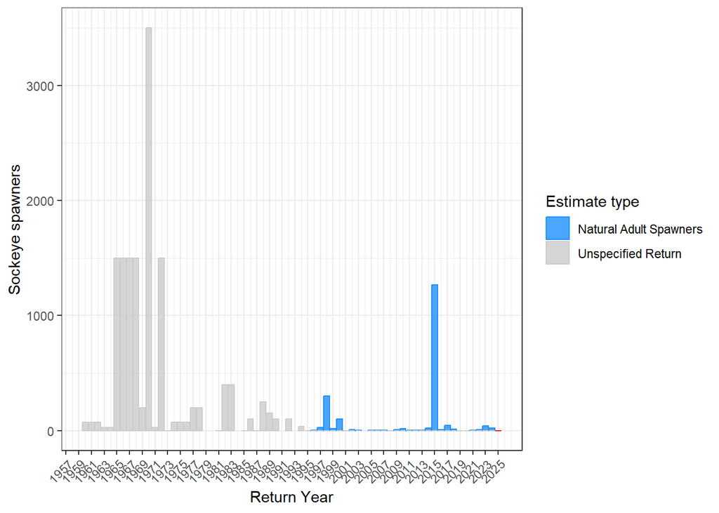

Figure: 2025 preliminary adult Sockeye escapement estimate (red outline) for entire San Juan system (including tributaries) relative to historical adult (blue) and unspecified (gray) escapement estimates. Gaps indicate years without estimates.

# 2 **Coho**

## 2.2 Area 20 raw vs expanded counts

Counts are expanded for % population estimated and/or observer efficiency, depending on survey conditions.

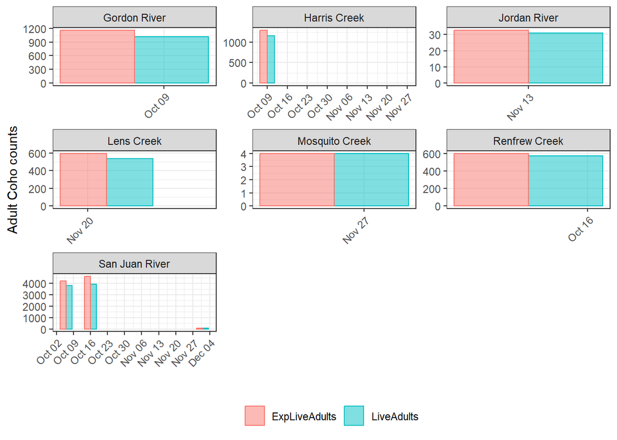

## 2.3 Counts & environmentals

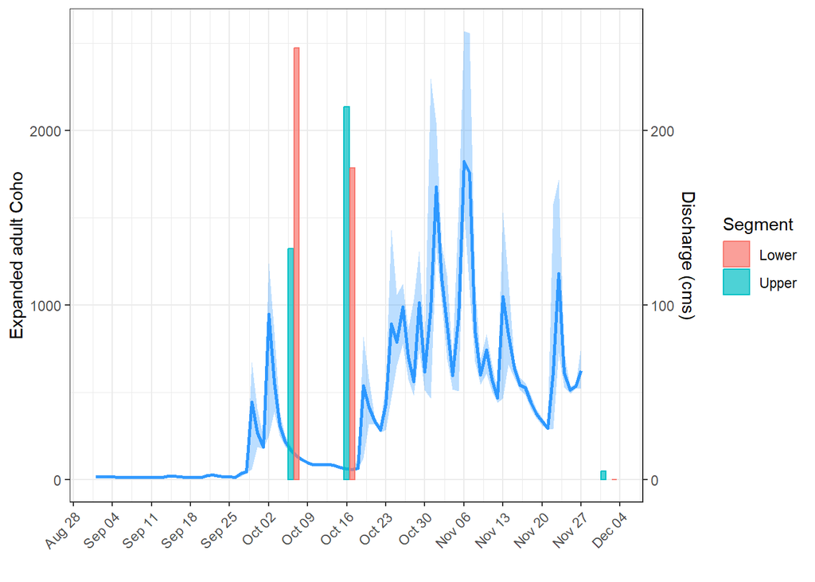

Figure: Coho counts (expanded live adults) and water levels (blue line) in the San Juan mainstem.

## 2.4 Behaviour & carcasses

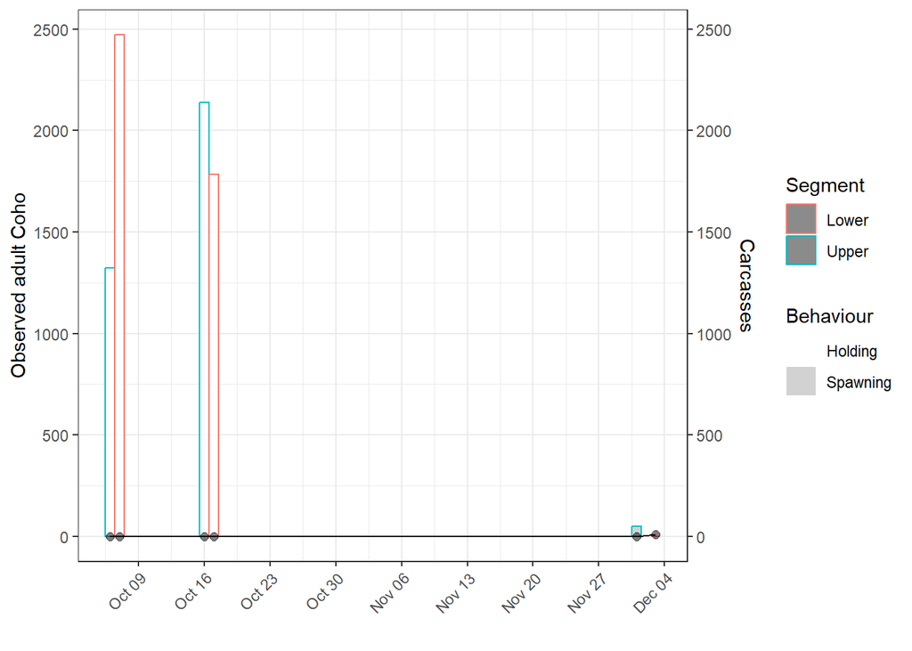

Figure: Expanded live adult Coho (bars) and carcasses (black line) in the San Juan mainstem. Bar fill colur indicates behaviour (spawning=gray, holding=white) while bar outline colour indicates river segment (lower=pink, mid=green, upper=blue).

## 2.5 Swim & fence counts

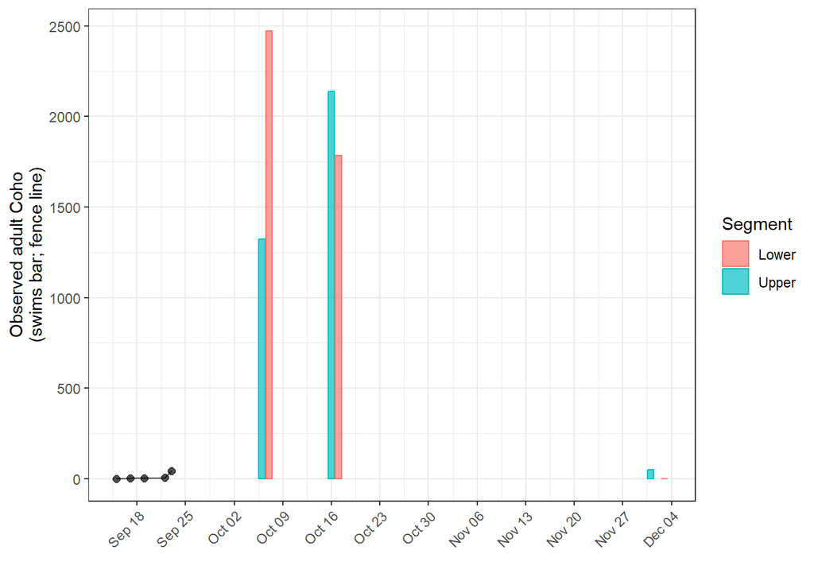

Figure: Coho swim counts (raw adults) in the San Juan mainstem relative to cumulative fence counts (black line). If no black line, then no coho were counted through the fence this year.

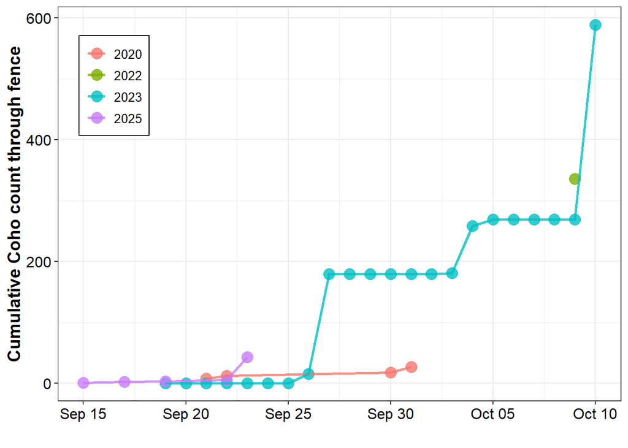

Figure: Cumulative fence counts for Coho over time. Fence operated by 4 Mile hatchery with install date usually just after Labour day and removal around Thanksgiving.

## 2.6 Tributaries

| trib_status | system | date | expanded_live_adults | dead_adults |
| --- | --- | --- | --- | --- |
| SJ trib | Harris | 2025-10-10 | 1160 | 1 |
|  | Lens | 2025-11-21 | 538 | 1 |
|  | Renfrew | 2025-10-14 | 328 | 0 |
|  | Renfrew | 2025-10-15 | 243 | 0 |
| NA | Barid | 2025-11-26 | NA | 0 |
|  | Brown | 2025-11-25 | NA | 0 |
|  | Fairy | 2025-11-25 | NA | 0 |
|  | Falls | 2025-11-26 | NA | 0 |
|  | Gordon | 2025-10-08 | 1019 | 0 |
|  | Jordan | 2025-11-13 | 31 | 0 |
|  | Mosquito | 2025-11-26 | NA | 1 |

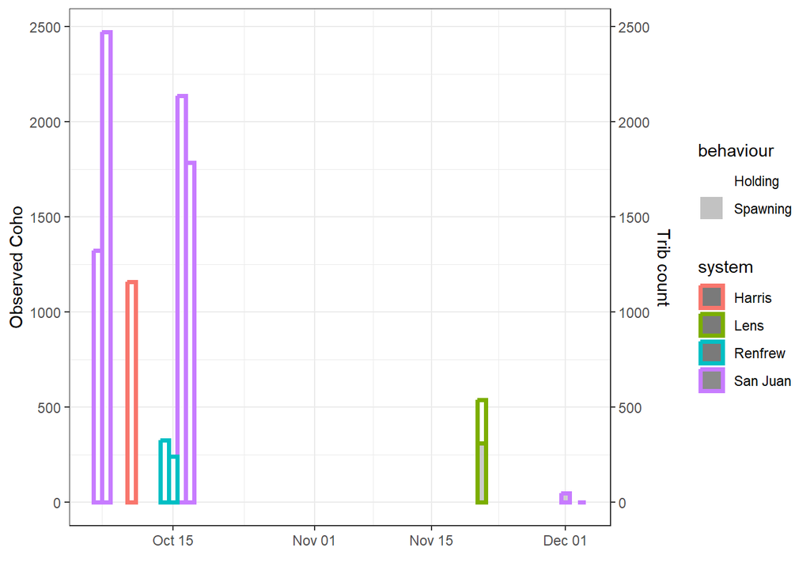

Figure: Mainstem and trib counts for Coho adults (unexpanded).

## 2.7 Area 20 preliminary escapement estimates (PL+D)

Table: Area 20 raw swim data (raw and expanded live and dead) for Coho.

[output not shown]

Table: Escapement estimates for each system. San Juan mainstem surveys were rolled up based on mid-point date for each of 3 complete survey events, and then the PL+D was selected based on the 3 survey events.

| ShortSpecies | SystemName | AdultRawPLD | AdultExpPLD | JackRawPLD | JackExpPLD | AdultRemovalsReco | JackRemovalsReco | FinalAdultEstimate | FinalJackEstimate |
| --- | --- | --- | --- | --- | --- | --- | --- | --- | --- |
| CO | Jordan River | 31 | 33 | 0 | 0 | 0 | 0 | 33 | 0 |
|  | San Juan River | 3923 | 4615 | 107 | 119 | 0 | 0 | 4615 | 119 |
|  | Falls Creek | 7 | 7 | 0 | 0 | 0 | 0 | 7 | 0 |
|  | Mosquito Creek | 5 | 5 | 1 | 1 | 0 | 0 | 5 | 1 |
|  | Fairy Creek | 17 | 17 | 1 | 1 | 0 | 0 | 17 | 1 |
|  | Renfrew Creek | 571 | 601 | 27 | 28 | 0 | 0 | 601 | 28 |
|  | Harris Creek | 1161 | 1290 | 0 | 0 | 0 | 0 | 1290 | 0 |
|  | Lens Creek | 539 | 599 | 131 | 146 | 0 | 0 | 599 | 146 |
|  | Gordon River | 1019 | 1155 | 0 | 0 | 0 | 0 | 1155 | 0 |

### 2.7.1 Estimate decision:

Parsing out the San Juan mainstem coho population from tributaries (Harris, Lens) was difficult for 2025 due to the timing of surveys. We can assume the Renfrew Creek population is in addition to these fish given the creek is below the extent of surveys for San Juan. However, it remains unclear what portion of the San Juan fish wound up in tributaries and/or the mainstem (or could have been double-counted).  
There were a total of 3,795 and 3,923 observed coho in the San Juan River on Oct 6/7 and Oct 16/17, respectively. None were spawning on either survey, and more coho moved into the upper San Juan on the later survey. A much later survey on Dec 1/3 noted no coho in the lower and only 48 spawning coho in the upper (only 9 dead coho in the lower).

The timing of these mainstem surveys alone would suggest most coho left the mainstem survey area and either went above the surveyed area, or into tributaries. Historical tagging indicates approximately 66% of the run tends to go into Harris, although this information needs to be renewed with modern methods (e.g., PIT tags).

**In absence of any other information, we will assume 66% of the total number went into Harris Creek, or 5908*0.66 = 3,899 live adults + 1 dead = 3,900. Subtracting 5908-3900 = 2,008 live coho + 1 dead = 2,009 coho spawning in the San Juan mainstem. Likewise for jacks this would equate to 58 total (expanded) jacks, 39 in Harris and 19 in the SJ mainstem.**

## 2.8 2025 compared to historical run timing and abundance

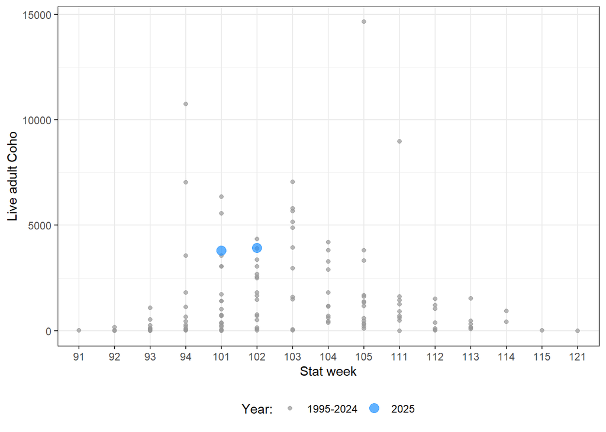

Figure: Raw swim counts (blue) from this year compared to historical raw swim counts. Stat weeks indicate the month (8=August, 12=December) and week of momth (1=first week, 2=2nd week, etc.), e.g., 81=First week of August, 91=First week of September, etc. Mainstem and tributary counts within a statweek are pooled to give run timing for the aggregate system (e.g., SJ + Harris + Lens).

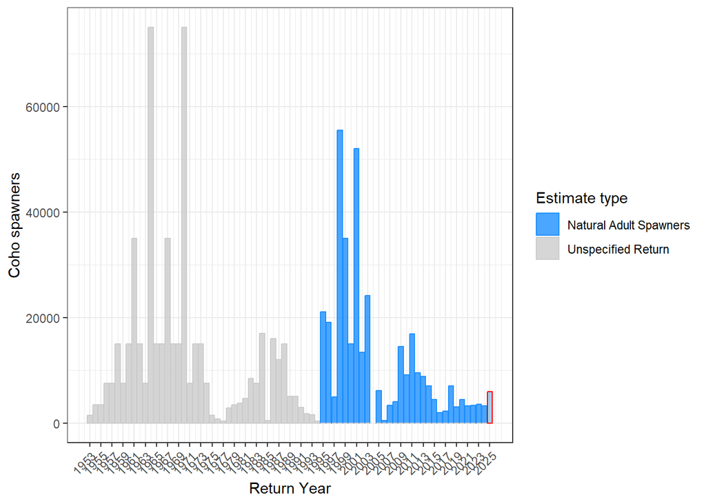

Figure: 2025 preliminary adult Coho escapement estimate (red outline) for entire San Juan system (including tributaries) relative to historical adult (blue) and unspecified (gray) escapement estimates. Gaps indicate years without estimates.

# 3 **Chum**

## 3.1 Area 20 raw vs expanded counts

Counts are expanded for % population estimated and/or observer efficiency, depending on survey conditions.

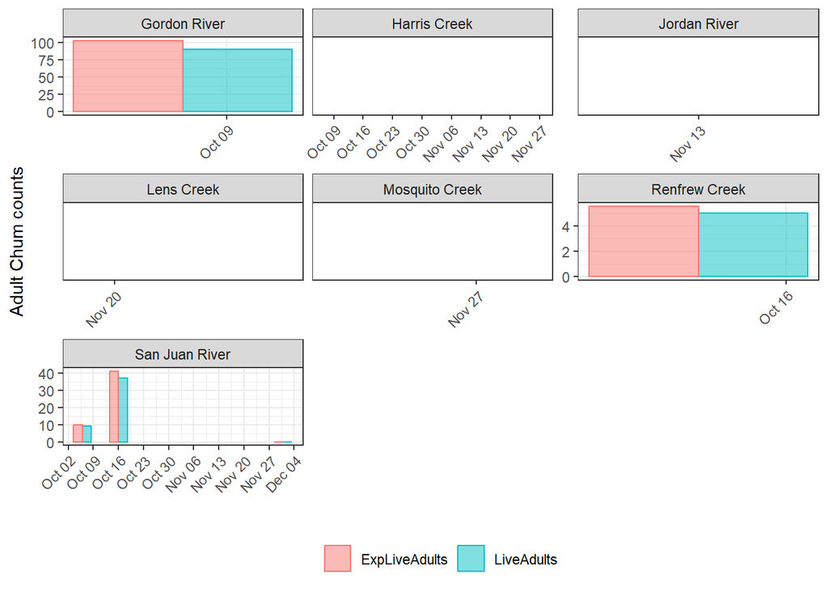

Figure: Raw live Adult Chum counts (blue) and expanded for OE/%habitat (pink).

## 3.2 Counts & environmentals

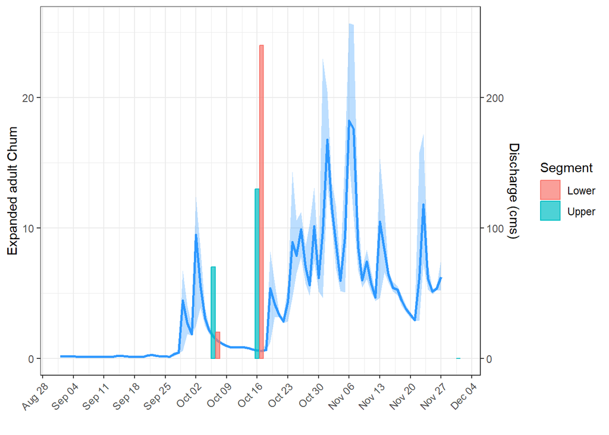

Figure: Chum counts (raw live adults) and water levels (blue line) in the San Juan mainstem.

## 3.3 Behaviour & carcasses

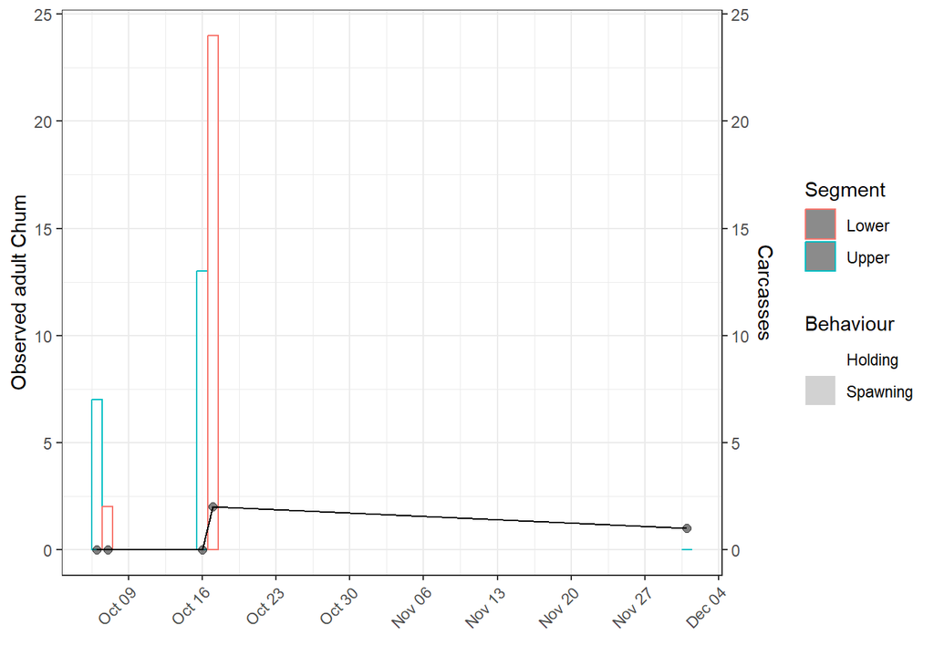

Figure: Raw live adult Chum (bars) and carcasses (black line) in the San Juan mainstem. Bar fill colour indicates behaviour (spawning=gray, holding=white) while bar outline colour indicates river segment (lower=pink, mid=green, upper=blue).

## 3.4 Swim & fence counts

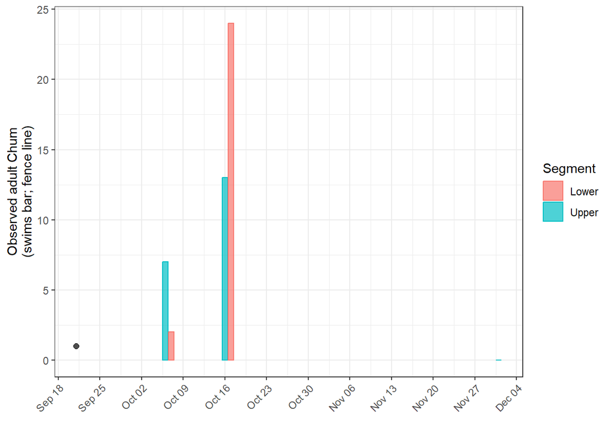

Figure: Chum swim counts (observed adults) in the San Juan mainstem relative to cumulative fence counts (black line).

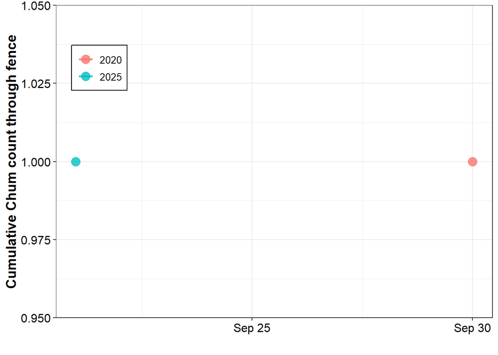

Figure: Cumulative fence counts for Chum over time. Fence operated by 4 Mile hatchery with install date usually just after Labour day and removal around Thanksgiving.

## 3.5 Tributaries

| trib_status | system | date | expanded_live_adults | dead_adults |
| --- | --- | --- | --- | --- |
| SJ trib | Renfrew | 2025-10-14 | 3 | 0 |
|  | Renfrew | 2025-10-15 | 2 | 0 |
| NA | Gordon | 2025-10-08 | 90 | 6 |
|  | Kuzman | 2025-11-24 | NA | 4 |

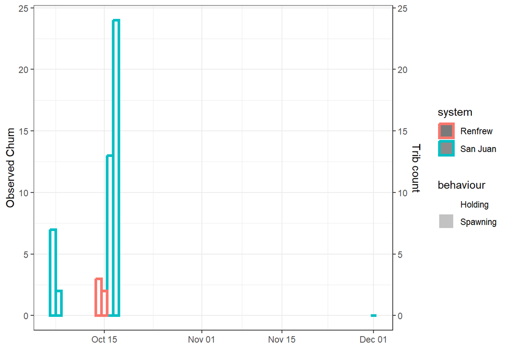

Figure: Mainstem and trib counts for Chum adults (unexpanded).

## 3.6 Area 20 preliminary escapement estimate (PL+D)

| ShortSpecies | Section_AreaInspected | SDate | WaterTemperature | WaterClarity | LiveAdults | DeadAdults | LiveJacks | DeadJacks | ExpLiveAdults | ExpDeadAdults | ExpLiveJacks | ExpDeadJacks | OverallReliability | EstPctSeen |
| --- | --- | --- | --- | --- | --- | --- | --- | --- | --- | --- | --- | --- | --- | --- |
| CM | FAIRY CREEK | 2025-11-25 | 99.0 | NA | NA | NA | NA | NA | NA | NA | NA | NA | NA | NA |
|  | FALLS CREEK | 2025-11-26 |  | NA | NA | NA | NA | NA | NA | NA | NA | NA | NA | NA |
|  | GORDON RIVER | 2025-10-08 | 9.5 | 3 - 5 m or to Bottom | 90 | 6 | NA | NA | 90 | NA | NA | NA | H | 1 |
|  | HARRIS CREEK | 2025-10-09 | 11.5 | 3 - 5 m or to Bottom | NA | NA | NA | NA | NA | NA | NA | NA | NA | NA |
|  |  | 2025-11-25 | 99.0 | NA | NA | NA | NA | NA | NA | NA | NA | NA | NA | NA |
|  | JORDAN RIVER | 2025-11-13 | 9.0 | 3 - 5 m or to Bottom | NA | NA | NA | NA | NA | NA | NA | NA | NA | NA |
|  | LENS CREEK | 2025-11-21 | 8.0 | 3 - 5 m or to Bottom | NA | NA | NA | NA | NA | NA | NA | NA | NA | NA |
|  |  | 2025-11-24 | 99.0 | NA | NA | NA | NA | NA | NA | NA | NA | NA | NA | NA |
|  | MOSQUITO CREEK | 2025-11-26 |  | NA | NA | NA | NA | NA | NA | NA | NA | NA | NA | NA |
|  | RENFREW CREEK | 2025-10-14 | 9.0 | 3 - 5 m or to Bottom | 3 | NA | NA | NA | 3 | NA | NA | NA | H | 1 |
|  |  | 2025-10-15 |  | 3 - 5 m or to Bottom | 2 | NA | NA | NA | 2 | NA | NA | NA | H | 1 |
|  | SAN JUAN RIVER | 2025-10-06 | 10.0 | 3 - 5 m or to Bottom | 7 | 0 | NA | NA | 7 | NA | NA | NA | H | 1 |
|  |  | 2025-10-07 | 10.5 | 3 - 5 m or to Bottom | 2 | 0 | NA | NA | 2 | NA | NA | NA | H | 1 |
|  |  | 2025-10-16 | 6.0 | 3 - 5 m or to Bottom | 13 | NA | NA | NA | 13 | NA | NA | NA | H | 1 |
|  |  | 2025-10-17 | 10.5 | 3 - 5 m or to Bottom | 24 | 2 | NA | NA | 24 | NA | NA | NA | H | 1 |
|  |  | 2025-12-01 | 4.0 | 3 - 5 m or to Bottom | 0 | 1 | NA | NA | 0 | NA | NA | NA | H | 1 |
|  |  | 2025-12-03 | 4.5 | 3 - 5 m or to Bottom | NA | NA | NA | NA | NA | NA | NA | NA | NA | NA |

Table: Escapement estimates for each system. San Juan mainstem surveys were rolled up based on mid-point date for each of 3 complete survey events, and then the PL+D was selected based on the 3 survey events.

| Year | ShortSpecies | SystemName | AdultRawPLD | AdultExpPLD | JackRawPLD | JackExpPLD | RecommendedAdultEstimate | AdultRemovalsReco | RecommendedJackEstimate | JackRemovalsReco | AdultRemovalsIncluded | JackRemovalsIncluded | EnumerationClass | IsFinal | AREA | n |
| --- | --- | --- | --- | --- | --- | --- | --- | --- | --- | --- | --- | --- | --- | --- | --- | --- |
| 2025 | CM | Jordan River | 0 | 0 | 0 | 0 | 0 | 0 | 0 | 0 | FALSE | FALSE | 5 | TRUE | 20 | 1 |
| 2025 | CM | San Juan River | 39 | 43 | 0 | 0 | 43 | 0 | 0 | 0 | FALSE | FALSE | 4 | TRUE | 20 | 1 |
| 2025 | CM | Falls Creek | 0 | 0 | 0 | 0 | 0 | 0 | 0 | 0 | FALSE | FALSE | 6 | TRUE | 20 | 1 |
| 2025 | CM | Mosquito Creek | 0 | 0 | 0 | 0 | 0 | 0 | 0 | 0 | FALSE | FALSE | 6 | TRUE | 20 | 1 |
| 2025 | CM | Fairy Creek | 0 | 0 | 0 | 0 | 0 | 0 | 0 | 0 | FALSE | FALSE | 6 | TRUE | 20 | 1 |
| 2025 | CM | Renfrew Creek | 5 | 6 | 0 | 0 | 6 | 0 | 0 | 0 | FALSE | FALSE | 5 | FALSE | 20 | 1 |
| 2025 | CM | Harris Creek | 0 | 0 | 0 | 0 | 0 | 0 | 0 | 0 | FALSE | FALSE | 5 | TRUE | 20 | 1 |
| 2025 | CM | Lens Creek | 0 | 0 | 0 | 0 | 0 | 0 | 0 | 0 | FALSE | FALSE | 5 | TRUE | 20 | 1 |
| 2025 | CM | Gordon River | 96 | 108 | 0 | 0 | 108 | 0 | 0 | 0 | FALSE | FALSE | 5 | FALSE | 20 | 1 |

### 3.6.1 Estimate decision:

Used expanded PL+D. Added in 4 dead chum in Kuzman as not likely these would have been double-counted (43 expanded live + 4 dead = 47 total).

## 3.7 2025 compared to historical run timing and abundance

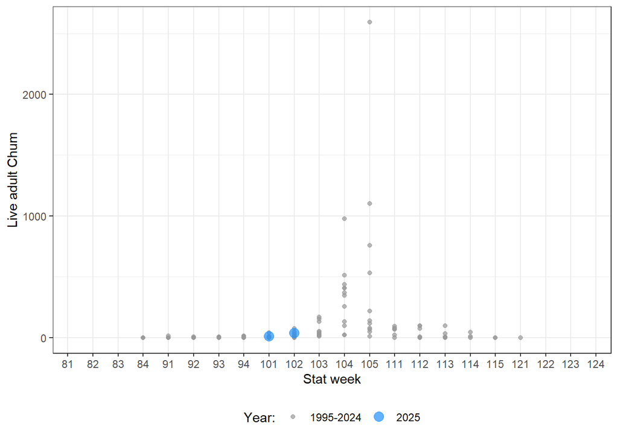

Figure: Raw swim counts (blue) from this year compared to historical raw swim counts. Stat weeks indicate the month (8=August, 12=December) and week of momth (1=first week, 2=2nd week, etc.), e.g., 81=First week of August, 91=First week of September, etc.

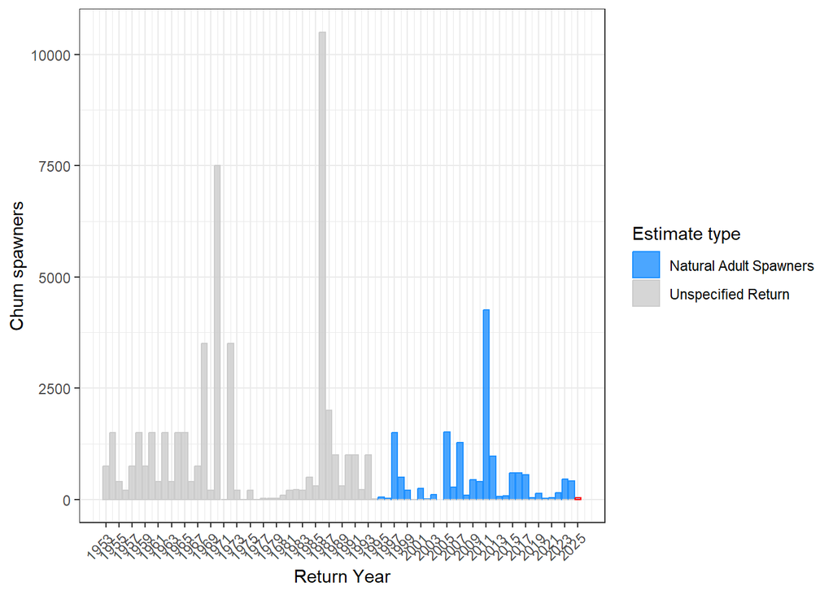

Figure: 2025 preliminary adult Chum escapement estimate (red outline) for entire San Juan system (including tributaries) relative to historical adult (blue) and unspecified (gray) escapement estimates. Gaps indicate years without estimates.

# 4 **Chinook**

## 4.2 Area 20 raw vs expanded counts

Counts are expanded for % population estimated and/or observer efficiency, depending on survey conditions.

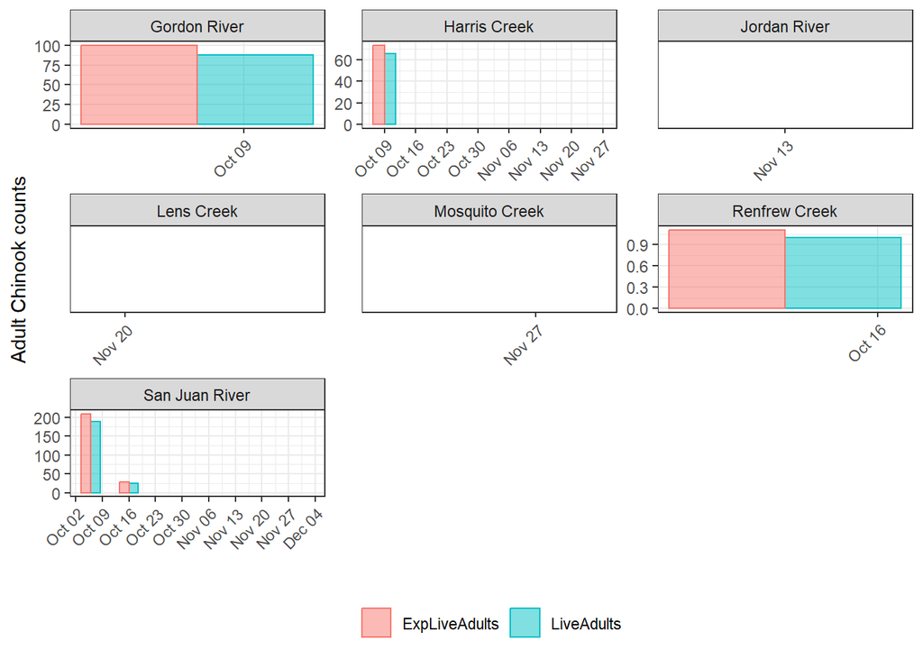

Figure: Observed adult Chinook counts (blue) and expanded for OE/% habitat (pink).

## 4.3 Counts & environmentals

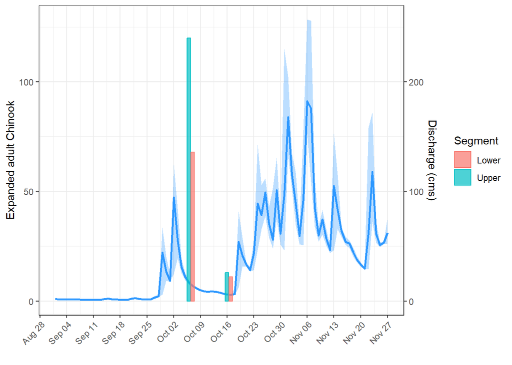

Figure: Chinook counts (expanded live adults) and water levels (blue line) in the San Juan mainstem.

## 4.4 Behaviour & carcasses

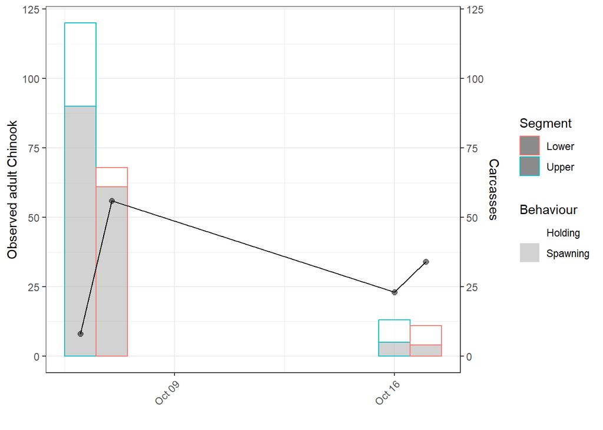

Figure: Expanded live adult Chinook (bars) and carcasses (black line) in the San Juan mainstem. Bar fill colour indicates behaviour (spawning=gray, holding=white) while bar outline colour indicates river segment (lower=pink, mid=green, upper=blue).

## 4.5 Swim & fence counts

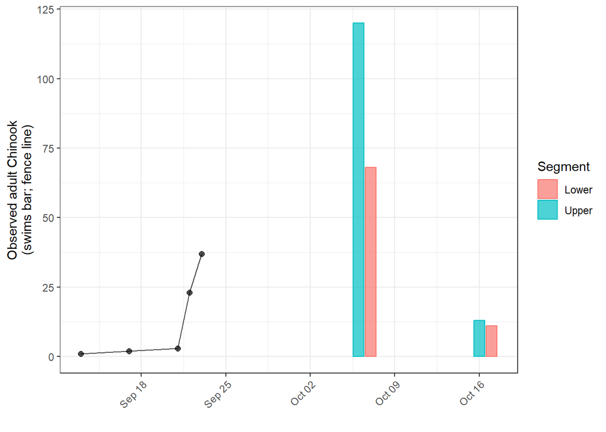

Figure: Chinook swim counts (observed adults) in the San Juan mainstem relative to cumulative fence counts (black line).

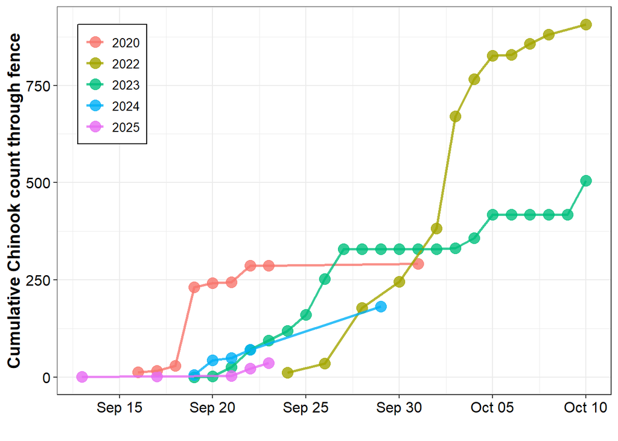

Figure: Cumulative fence counts for Chinook over time. Fence operated by 4 Mile hatchery with install date usually just after Labour day and removal around Thanksgiving.

## 4.6 Tributaries

| trib_status | system | date | expanded_live_adults | dead_adults |
| --- | --- | --- | --- | --- |
| SJ trib | Harris | 2025-10-10 | 66 | 6 |
|  | Renfrew | 2025-10-14 | 1 | 9 |
|  | Renfrew | 2025-10-15 | 0 | 11 |
| NA | Gordon | 2025-10-08 | 88 | 22 |

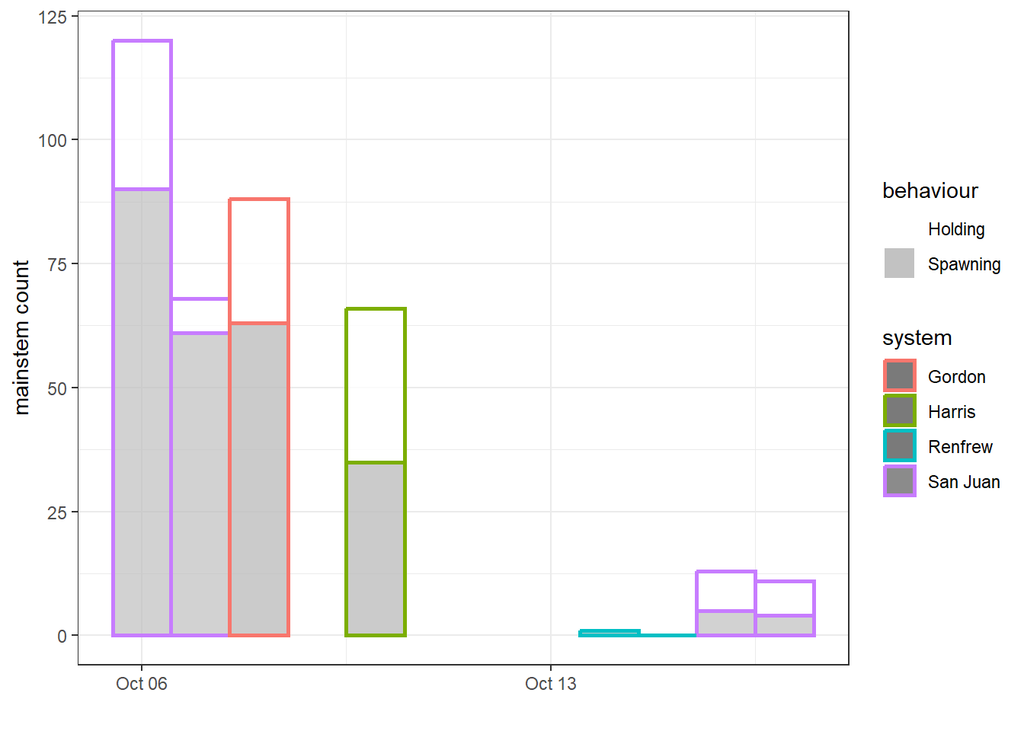

Figure: Mainstem and trib counts for Chinook adults (unexpanded).

## 4.7 Area 20 preliminary escapement estimate (PL+D)

[output not shown]

Table: Escapement estimates for each system. San Juan mainstem surveys were rolled up based on mid-point date for each of 3 complete survey events, and then the PL+D was selected based on the 3 survey events.

| Year | ShortSpecies | SystemName | AdultRawPLD | AdultExpPLD | JackRawPLD | JackExpPLD | RecommendedAdultEstimate | AdultRemovalsReco | RecommendedJackEstimate | JackRemovalsReco | AdultRemovalsIncluded | JackRemovalsIncluded | EnumerationClass | IsFinal | AREA | n |
| --- | --- | --- | --- | --- | --- | --- | --- | --- | --- | --- | --- | --- | --- | --- | --- | --- |
| 2025 | CN | Jordan River | 0 | 0 | 0 | 0 | 0 | 0 | 0 | 0 | FALSE | FALSE | 5 | TRUE | 20 | 1 |
| 2025 | CN | San Juan River | 250 | 271 | 0 | 0 | 271 | 326 | 0 | 0 | FALSE | FALSE | 4 | FALSE | 20 | 1 |
| 2025 | CN | Falls Creek | 0 | 0 | 0 | 0 | 0 | 0 | 0 | 0 | FALSE | FALSE | 6 | TRUE | 20 | 1 |
| 2025 | CN | Mosquito Creek | 0 | 0 | 0 | 0 | 0 | 0 | 0 | 0 | FALSE | FALSE | 6 | TRUE | 20 | 1 |
| 2025 | CN | Fairy Creek | 0 | 0 | 0 | 0 | 0 | 0 | 0 | 0 | FALSE | FALSE | 6 | TRUE | 20 | 1 |
| 2025 | CN | Renfrew Creek | 21 | 21 | 0 | 0 | 21 | 0 | 0 | 0 | FALSE | FALSE | 5 | FALSE | 20 | 1 |
| 2025 | CN | Harris Creek | 72 | 79 | 0 | 0 | 79 | 0 | 0 | 0 | FALSE | FALSE | 5 | FALSE | 20 | 1 |
| 2025 | CN | Lens Creek | 0 | 0 | 0 | 0 | 0 | 0 | 0 | 0 | FALSE | FALSE | 5 | TRUE | 20 | 1 |
| 2025 | CN | Gordon River | 110 | 122 | 0 | 0 | 122 | 0 | 0 | 0 | FALSE | FALSE | 5 | FALSE | 20 | 1 |

### 4.7.1 Estimate decision:

For 2025 estimate, went with PL+D (expanded) estimate for SJ. Did not subtract any trib fish this year as most were spawning on the first peak swim and also spawning when seen in tribs, so it’s very unlikely fish were double-counted on their way to Harris/Lens. Broodstock will be added in addition to spawners. Notable very low escapement year for San Juan, escapement estimate confirmed by PFN. Other anecdotes: lowest count through fence yet; took 7 sets to get broodstock when it usually takes ~2; deadpitch survey had to put in a lot of effort to get as many samples as we got in 1 day in 2024. All supports a very low return.

## 4.8 2025 compared to historical run timing and abundance

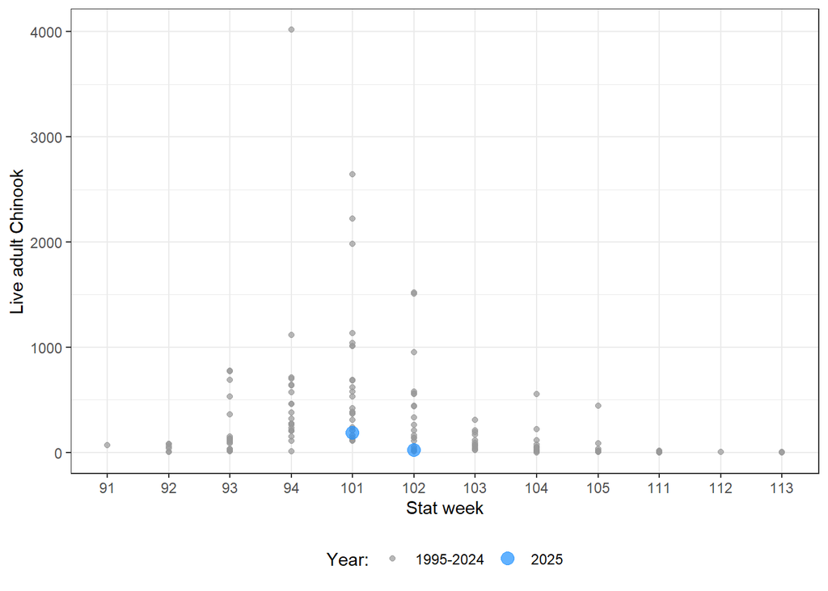

Figure: Raw swim counts (blue) from this year compared to historical raw swim counts. Stat weeks indicate the month (8=August, 12=December) and week of momth (1=first week, 2=2nd week, etc.), e.g., 81=First week of August, 91=First week of September, etc. Mainstem and tributary counts within a statweek are pooled to give run timing for the aggregate system (e.g., SJ + Harris + Lens + Renfrew).

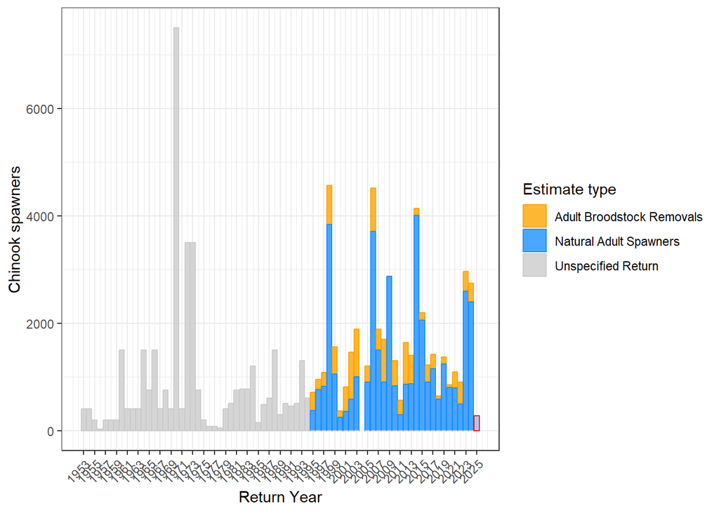

Figure: 2025 preliminary adult Chinook escapement estimate (red outline) relative to historical adult (blue) and unspecified (gray) escapement estimates. Gaps indicate years without estimates.